# CS 489: Neural Networks

```
Notes by Shaw Tan
```

# Neuron Models

## The Neuron

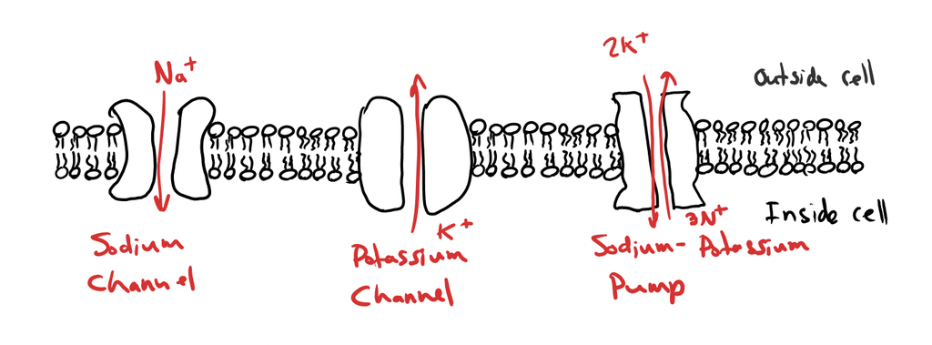

neuron_membrane

- *Ions* are molecules or atoms that carry a charge
  - the number of electrons do not match the number of protons
- Cell membrane contains ion channels that allow ions through
  - Sodium Channel: Na+ into cell
  - Potassium Channel: K+ out of cell
  - Sodium-Potassium Pump: 2K+ in, 3N+ out
- **Membrane Potential**: voltage difference across the membrane
- **Action Potential**: spike of electrical activity that travels along the **axon** to the **synapses**. The *synapses* pass signals to other neurons

## Hodgkin-Huxley Model

- Model of spikes based on non-linear interactions between voltage and ion channels
- Problem: Takes many time steps to model a spike

The fraction of K+ channels open is *n*<sup>4</sup>
$$\frac{d n}{d t} = \frac{1}{\tau_n(v)}(n_\infty(v) - n)$$

The fraction of Na+ ion channels open is *m*<sup>3</sup>*h*
$$\frac{d m}{d t} = \frac{1}{\tau_m(v)}(m_\infty(v) - m)$$
$$\frac{d h}{d t} = \frac{1}{\tau_h(v)}(h_\infty(v) - h)$$

Let *J*<sub>*i**n*</sub> be the input current

The change in V is then
$$C \frac{dV}{dt} = J_{in} - g_L(V-V_L) - g_{Na}m^3h(V - V_{Na}) - g_Kn^4(V-V_K)$$

The following graph shows how V changes with current

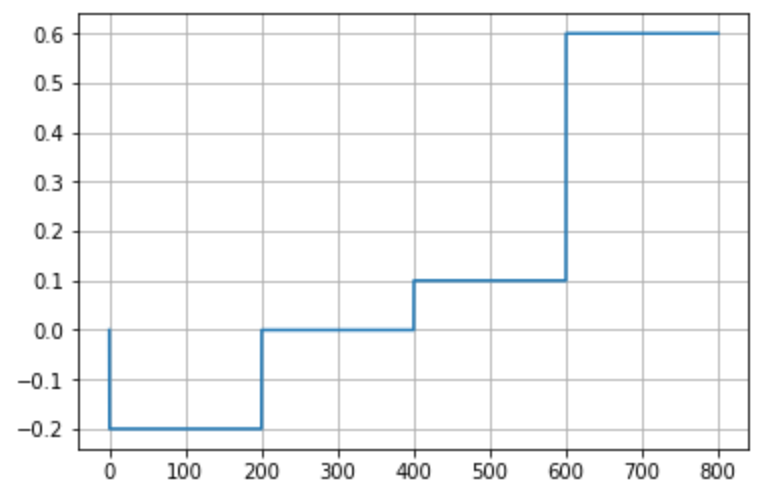

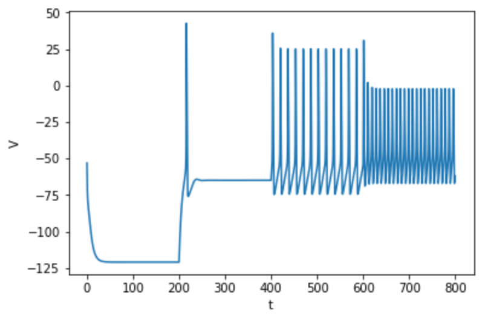

## Leaky Integrate-and-Fire (LIF) Model

- Only considers the sub-threshold membrane potential
- Does not model voltage during spike
- Only records when spikes occur

$$\begin{align*} %*
C \frac{d V}{d t} &= J_{in} - g_L(V-V_L) \\
\implies \tau_m \frac{d V}{d t} &= V_{in} - (V-V_L) \quad\text{ if $V < V_{th}$} \\
\text{Let } v &= \frac{V-V_L}{V_{th} - V_L} \qquad\text{ for $v < 1$} \\
\tau_m \frac{dv}{dt} &= \tau_m \frac{d}{dt}\frac{V-V_L}{V_{th} - V_L} \\
&= \tau_m \frac{1}{V_{th} - V_L} \frac{d V}{d t} \\
&= \frac{V_{in} - (V-V_L)}{V_{th} - V_L} \\
&= v_{in} - v\\
\end{align*} %*$$

$$\tau_m \frac{d v}{d t} = v_{in} - v$$
$$\tau_s \frac{d s}{d t} = -s$$

where *v* < 1

Also, $v(t) = v_{in} (1 - e^{\frac{-t}{r_m}})$ is a solution to $\tau_m \frac{d v}{d t} = v_{in} - v$

The firing time $t_{isi} = \tau_{ref} - \tau_{m} \ln(1 - \frac{1}{v_{in}})$

The steady-state firing rate *G*(*v*<sub>*i**n*</sub>) is
$$G(v_{in}) = \begin{cases}
\frac{1}{\tau_{ref} - \tau_m \ln(1 - \frac{1}{v_in})} &\text{for $v_{in} > 1$} \\
0 & \text{otherwise}
\end{cases}$$

## Activation Functions

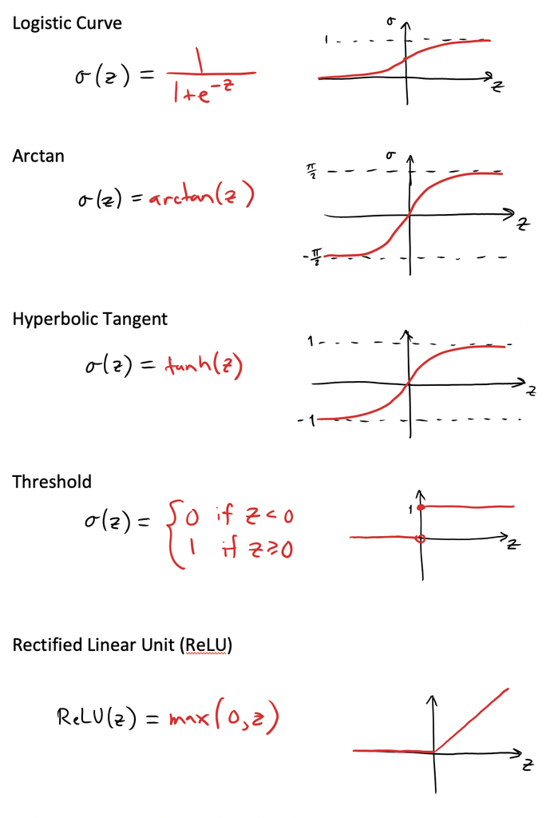

activation_functions

## Synapses

- In a network, input comes from other neurons
- **Synapse**: The junction where one neuron communicates with the next
- Synaptic process:
  1. Pre-synaptic action potential (travels up axon)
  2. Cause release of neurotransmitters
  3. Neurotransmitters bind to receptors on the post-synaptic neuron
  4. Opens (or closes) ion channels, changing the membrane potential
- Some synapses are fast (10ms), and some are slow (300ms)

The Post-Synaptic Current (PSC) can be written as
$$h(t) = \begin{cases}
kt^ne^{\frac{-t}{\tau_s}} & \text{if $t \geq 0$} \\
0 & \text{if $t < 0$}
\end{cases}$$

### Spiking

- Multiple spikes form a *spike train* which can be modelled as a sum of Dirac delta function

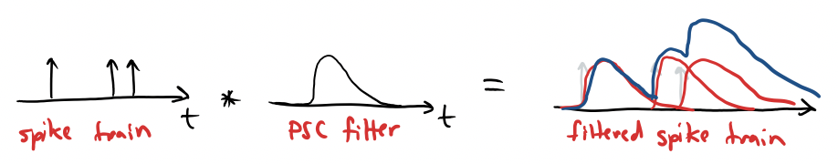

## Connection Weight

- The total current induced by an action potential depends on:
  1. Number and sizes of synapses
  2. Amount and type of neurotransmitter
  3. Number and type of receptors
- **Connection Weight**: combined factors influencing input to a neuron
- We use **weight matrices** to store connection weights between neurons
- TODO: figure out math

# Supervised Learning

## Learning

1. **Supervised Learning**:
   - Output is known
   - Can compute error and use it to adjust the network
2. **Unsupervised Learning**:
   - Output unknown
   - Learning by finding efficient representations on the input
   - Bottleneck layer?
3. **Reinforcement Learning**:
   - General feedback given
   - e.g Win or loss in chess

## Supervised Learning

- Neural network is a map from input space to output space
- We feed the network input and target, and want to get the weights close to the target

### Mappings

1. **Regression**
   - Output is continuous in a range
   - Use a *linear* activation function (identity, threshold) with *MSE* loss function
2. **Classification**
   - Output is in categories
   - e.g MNIST
   - Use *logistic* activation function with *cross entropy* loss function

### Optimization

- Learning with a cost function is just an optimization problem
- We want to find the weights and biases that minimize the expected cost between output and target

Let *x⃗* be the input  
Let *θ* be the weights and biases  
Let *t⃗* be the target  
Let *y⃗* = *f*(*x⃗*; *θ*) be the network mapping

min<sub>*θ*</sub>*E*[*E*(*f*(*x⃗*;*θ*),*t⃗*(*x⃗*))]

## Loss Functions

- Quantifies how close the output is to the target

Let *x⃗* be the input  
Let *t⃗* be the target  
Let *y⃗* be the output of our network

### Mean Squared Error (MSE)

$$E(\vec{y}, \vec{t}) = \frac{1}{N} \sum_{i=1}^N \vert y_i - t_i \vert_2^2$$

- Often used with linear activation functions or ReLu because they afford a larger output range

### Cross Entropy

- Works based on probability magic with Bernoulli distributions (TODO)
- Assumes that output values are in the range $[0, 1]$

$$E(\vec{y}, \vec{t}) = - \sum_{i=1}^N t_i\ln y_i + (1-t_i)\ln(1-y_i)$$

### Softmax

$$\text{softmax}(z)_i = \frac{e^{z_i}}{\sum_j e^{z_j}} %_$$

### One-hot

- The largest element is set to 1, and the others 0

## Perceptrons

We come up with weights so that *y* = *W⃗**x⃗* + *b* matches the target.

This is a linear equation so it only works for *linearly separable data*.

## Gradient Descent Learning

Let *y⃗* = *f*(*x⃗*; *θ*) be the operation of the network  
Let *E*(*y⃗*, *t⃗*) be the cost function

Neural learning is the optimization problem  
min<sub>*θ*</sub>*E*[*E*(*f*(*x⃗*;*θ*),*t⃗*(*x⃗*))]

The gradient of *E* is
$$\nabla_\theta E = \left[\frac{\partial E}{\partial \theta_0}, \frac{\partial E}{\partial \theta_1}, \dots, \frac{\partial E}{\partial \theta_p}\right]^T$$

In gradient descent, you want to *minimize* the objective function by stepping in the *opposite* direction of the gradient vector.

The partial derivatives can be estimated using finite differencing:
$$\frac{d f}{d \theta} \approx \frac{f(\theta + \delta \theta) - f(\theta - \delta \theta)}{2 \delta \theta}$$

We update the variable by $\text{LR} \times -\frac{\partial E}{\partial \theta_1}$

## Error Backpropagation

To apply gradient descent on a multi-layer network, we need to calculate the gradients of the error with respect to the deeper connection weights and biases.

Consider a 3 layer network with input nodes *x*<sub>1</sub>, *x*<sub>2</sub>, *x*<sub>3</sub>, hidden nodes *h*<sub>1</sub>, *h*<sub>2</sub>, *h*<sub>3</sub>, *h*<sub>4</sub>, and output nodes *y*<sub>1</sub>, *y*<sub>2</sub>.

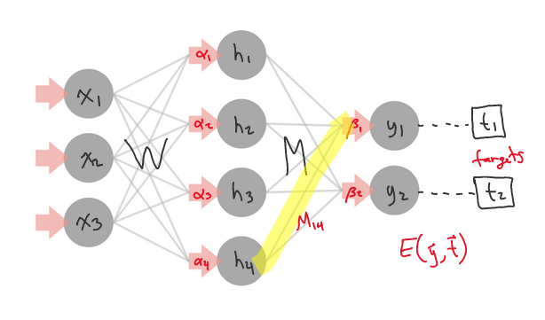

Let *α* = *W**x⃗* + *a⃗* be the input current to *h*  
Let *β* = *M**h⃗* + *b⃗* be the input current to *y*

To calculate $\frac{\partial E}{\partial M_{14}}$,
*E*(*y⃗*, *t⃗*) = *E*(*σ*(*β⃗*), *t⃗*)
$$\beta_1 = \sum_{i=1}^4 M_{1i} h_i + b_1$$
$$\begin{align*} %*
\frac{\partial E}{\partial M_{14}} &= \frac{\partial E}{\partial \beta_1} \frac{\partial \beta_1}{\partial M_{14}} \\
\frac{\partial \beta_1}{\partial M_{14}} &= \frac{d}{d M_{14}} \sum_{i=1}^4 M_{1i}h_i + b_1 \\
&= h_4 \\
\frac{\partial E}{\partial \beta_1} &= \frac{\partial E}{\partial y_1} \frac{d y_1}{d \beta_1} \\
&= \frac{\partial E}{\partial y_1} \sigma'(\beta_1) \\
\implies \frac{\partial E}{\partial M_{14}} &= \frac{\partial E}{\partial y_1} \frac{d y_1}{d \beta_1} h_4 \\
\end{align*} %*$$

To calculate $\frac{\partial E}{\partial W_{12}}$,
*E*(*y⃗*, *t⃗*) = *E*(*σ*(*β⃗*), *t⃗*) = *E*(*σ*(*M**h⃗* + *b⃗*), *t⃗*)
*h⃗* = *σ*(*α⃗*)
$$\alpha_1 = \sum_{i=1}^3 W_{1i} x_i + a_1$$
$$\begin{align*} %*
\frac{\partial E}{\partial W_{12}} &= \frac{\partial E}{\partial \alpha_1} \frac{\partial \alpha_1}{\partial W_{12}} \\
\frac{\partial \alpha_1}{\partial W_{12}} &= \frac{d}{d \alpha_1} \sum_{i=1}^3 M_{1i}x_i + a_1 \\
&= x_2 \\
\frac{\partial E}{\partial \alpha_1} &= \frac{d h_1}{d \alpha_1} \frac{\partial E}{\partial h_1} \\
&= \sigma'(\alpha_1) \left(\sum_{i=1}^2 \frac{\partial \beta_i}{\partial h_1} \frac{\partial E}{\partial \beta_i} \right)\\
&= \sigma'(\alpha_1) \left(\sum_{i=1}^2 M_{i1}\frac{\partial E}{\partial \beta_i}\right) \\
\implies \frac{\partial E}{\partial W_{12}} &= \sigma'(\alpha_1) \begin{bmatrix}M_{11} & M_{21}\end{bmatrix}\begin{bmatrix}\frac{\partial E}{\partial \beta_1} \\ \frac{\partial E}{\partial \beta_2}\end{bmatrix}\\
\end{align*} %*$$

*In general*, for any layer,

Let *z⃗*<sup>(*l* + 1)</sup> = *W*<sup>(*l* + 1)</sup>*z⃗*<sup>(*l*)</sup> + *b⃗*<sup>(*l* + 1)</sup> be the input current to layer *l*  
Let *h⃗*<sup>(*l*)</sup> = *σ*(*z*<sup>(*l*)</sup>) be the activations at layer *l*

$$\frac{\partial E}{\partial z^{(l)}} = \frac{d h^{(l)}}{d z^{(l)}} \odot \left(W^{(l)}\right)^T \frac{\partial E}{\partial z^{(l+1)}}$$

$$\frac{\partial E}{\partial W^{(l)}} = \frac{\partial E}{\partial \vec{z}^{(l+1)}} \frac{d \vec{z}^{(l+1)}}{d W^{(l)}} = \frac{\partial E}{\partial \vec{z}^{(l+1)}} \vec{h}^{(l)}$$

$$\frac{\partial E}{\partial \vec{b}^{(l)}} = \frac{\partial E}{\partial \vec{z}^{(l)}} \frac{d \vec{z}^{(l)}}{d \vec{b}^{(l)}} = \frac{\partial E}{\partial \vec{z}^{(l)}}$$

#### Hadamard Product

$$\begin{bmatrix}
a & b
\end{bmatrix}
\odot
\begin{bmatrix}
c & d
\end{bmatrix}
=
\begin{bmatrix}
ac & bd
\end{bmatrix}$$

## Training and Testing

- Data is broken up into
  - Training set
  - Validation set: taken from the training set and used to evaluate performance
  - Test set: used to evaluate the model
- Avoids inflated accuracy from overfitting
  - **Overfitting**: When the model starts to fit the noise specific to the training set, instead of the underlying model
- Every passthrough of the training data is an **epoch**

## Preventing Overfitting

- A complex model (more degrees of freedom) can be hyper-adapted to the training set and start to fit the noise
  - This makes the training error *very* small
- Problematic because the model will not generalize to new samples
  - Test error will be much bigger than training error
- There are **regularization** techniques to prevent overfitting

### Weight Decay

- Add magnitude of weights to loss function
- Creates preference for solutions with smaller weights
  *Ẽ*(*y⃗*, *t⃗*; *θ*) = *E*(*y⃗*, *t⃗*) + *λ*|*θ*|<sub>*F*</sub><sup>2</sup>
  $$\frac{\partial \tilde{E}}{\partial \theta_i} = \frac{\partial E}{\partial \theta_i} + 2\lambda \theta_i$$

We usually usually choose *λ* = *K*/*C*

#### Frobenius Norm

|*θ*|<sub>*L*</sub><sup>2</sup> = ∑<sub>*i*</sub>*θ*<sub>*i*</sub><sup>2</sup>  
Frobenius Norm is a matrix norm defined as the square root of the sum of the absolute squares of its elements.

We can also use the *L*<sub>1</sub> norm  
*L*<sub>1</sub>(*θ*) = ∑<sub>*i*</sub>|*λ*<sub>*i*</sub>|  
The *L*<sub>1</sub> norm favours sparsity where most weights are 0.

### Data Augmentation

- Include a wider variety of samples so that noise is less of a factor
- For image input, we can *shift* or *rotate* the images (as long as it does not change the label)

### Dropout

- In an iteration, ignore a large portion (usually 50%) of the hidden nodes
- Set those nodes to 0 for that iteration
- We need to proportionally increase the signal *z* to compensate for the reduced output
- Similar to training a lot of different networks
- Network needs to find a model that is robust to loss of nodes

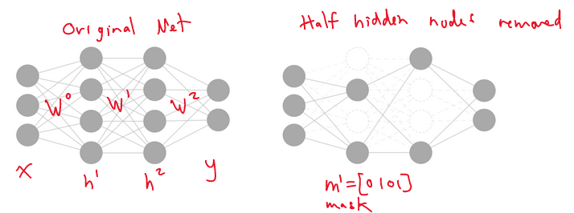

dropout_network

Let *m*<sup>*i*</sup> be a mask on layer *i*

Learning will work as follows:

Feedforward:
$$\begin{align*} %*
z^1 &= W^0x+b^1 \\
\hat{h}^1 &= \sigma(z^1) \\
\end{align*} %*$$

> Apply mask:

$$\begin{align*} %*
h^1 &= \hat{h}^i \odot m^1 \\
\end{align*} %*$$

> Double weights to compensate for the hidden nodes:

Backprop:
$$\begin{align*} %*
\frac{\partial E}{\partial z^1}
&= \frac{\partial 2h^1}{\partial z^1} \odot (W^1)^T \frac{\partial E}{\partial z^2}
= 2\frac{\partial h^1}{\partial z^1} \odot (W^1)^T \frac{\partial E}{\partial z^2} \\
\frac{\partial E}{\partial W^1}
&= \frac{\partial z^2}{\partial W^1} \frac{\partial E}{\partial z^2}
= 2h^1 \frac{\partial E}{\partial z^2}
\end{align*} %*$$

*Generally*, Let *d* be the proportion of nodes kept, 0 < *d* ≤ 1

Feedforward:
$$\begin{align*} %*
z^1 &= W^0x+b^1 \\
h^{(i)} &= \sigma(z^{(i)}) \odot m^{(i)} \\
z^{(i+1)} &= \frac{1}{d}W^{(i)}x+b^{(i+1)} \\
\end{align*} %*$$

Backprop:
$$\begin{align*} %*
\frac{\partial E}{\partial z^{(i)}}
&= \frac{\partial E}{\partial z^{(i+1)}} \left(\frac{1}{d} (W^{(i)})^T \right)\odot \frac{\partial h^{(i)}}{\partial z^{(i)}} \\
\frac{\partial E}{\partial W^{(i)}}
&= \frac{1}{d} \frac{\partial E}{\partial z^{(i+1)}} \frac{\partial h^{(i)}}{\partial z^{(i)}}
\end{align*} %*$$

## Deep Neural Networks

### Universal Approximation Theorem

Let *I*<sub>*m*</sub> be the *m*-dimensional unit hypercube [0, 1]<sup>*m*</sup>  
Let *C*(*I*<sub>*m*</sub>) be the space of continuous functions on *I*<sub>*m*</sub>

Then, given any *ϵ* > 0 for any function *f* ∈ *C*(*I*<sub>*m*</sub>), integer *N*, real constants *v*<sub>*i*</sub>, *b*<sub>*i*</sub> ∈ ℝ, real vectors *w*<sub>*i*</sub> ∈ ℝ<sup>*m*</sup>, we can define
$$F(x) = \sum_{i=1}^N v_i \phi(w_i^Tx + b_i)$$
such that
|*F*(*x*) − *f*(*x*)| < *ϵ*

So *F* is an approximation of *f*.

- Thus, any real-valued, continuous, function can be approximated by a single-layer neural network.
- However, the number of hidden nodes needed grows exponentially, so deeper networks are preferred
- Deeper networks run into problems too

#### Vanishing Gradient Problem

- When the current is large in magnitude, the slope of the activation function (for sigmoid and tanh) gets very close to 0.
- As a result, $\frac{\partial E}{\partial z} \approx 0$
- The gradient gets smaller the deeper you go and there’s no learning
- e.g In a network with 4 hidden layers of one node each
  - $\frac{\partial E}{\partial z^{(4)}} = (y - t)w^{(4)} \sigma'(z^{(4)})$
  - $\frac{\partial E}{\partial z^{(1)}} = (y - t) \prod_{i=1}^4 w^{(i)} \sigma'(z^{(i)})$
  - Since *σ*(*i*) ≤ 0.25, the gradient will decrease by at least a factor of 4 every layer

#### Exploding Gradient Problem

- When there are large weights and biases such that *z* ≈ 0, the $\frac{\partial E}{\partial z}$ compound in each layer and become large
- e.g x = 0.5, W = 8, b = -4
- Rare because weights and biases need to compensate to get into the sweet spot

## Enhancing Optimization

### Batch Gradient Descent

- Data: array of (input, target) pairs [(*x⃗*<sub>1</sub>, *t⃗*<sub>1</sub>), …, (*x⃗*<sub>𝕡</sub>, *t⃗*<sub>ℙ</sub>)]
- We can put them into matrices *X* = [*x⃗*<sub>1</sub>…*x⃗*<sub>ℙ</sub>] and *T* = [*t⃗*<sub>1</sub>…*t⃗*<sub>ℙ</sub>]
- This allows us to process all $ℙ$ inputs in one calculation
- Problem: processing the entire database for each update can be slow

### Stochastic Gradient Descent

- Randomly choose ‘mini-batches’ from our dataset to use as input
- More stable than single-sample, and faster than full-dataset

### Momentum

- If the gradient is in a half-pipe shape, gradient descent can be inefficient since you keep going back and forth along the walls
- We can add momentum to smooth out the trajectory
- This helps smooth out oscillations and prevent getting stuck in local minima

Let $V = \frac{d D}{d t}$ be the velocity  
Let $A = \frac{d V}{d t}$ be the acceleration

By Euler’s method,  
*D*<sub>*n* + 1</sub> = *D*<sub>*n*</sub> + *δ**t**V*<sub>*n*</sub>  
*V*<sub>*n* + 1</sub> = (1 − *v*)*V*<sub>*n*</sub> + *δ**t**A*<sub>*n*</sub>  
*v* ∈ (0, 1) is the resistance (friction).

The distance formula is similar to our weight update formula
$$W_{n+1} = W_n - \kappa\frac{\partial E}{\partial W_n}$$

Instead of $V = \frac{\partial E}{\partial W_n}$, we let $A = \frac{\partial E}{\partial W_n}$.
$$\implies V_{n+1} = (1-r)V_n - \frac{\partial E}{\partial W} = \beta V_n + (1-\beta)\frac{\partial E}{\partial W}$$
*W*<sub>*n* + 1</sub> = *W*<sub>*n*</sub> − *κ**V*<sub>*n* + 1</sub>

# Unsupervised Learning

## Hopfield Networks

- **Content-addressable memory (CAM)**: system that can take part of a pattern and produce the most likely match from memory
- Hopfield: use a neural network as a CAM
  - Network converges to the closest pattern when shown a partial pattern

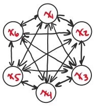

Each node in the network is `-1` or `1`
*x*<sub>*i*</sub> ∈ { − 1, 1} *i* = 1, …, *N*
$$x_i = \begin{cases}
-1 &\text{if $\sum_{j \neq i} W_{ij}x_j < b_i$} \\
1 &\text{if $\sum_{j \neq i} W_{ij}x_j \geq b_i$} \\
\end{cases}$$
Assume *b*<sub>*i*</sub> = 0

So set *W*<sub>*i**j*</sub> > 0 if *x*<sub>*i*</sub> and *x*<sub>*j*</sub> have the same state, and *W*<sub>*i**j*</sub> < 0 if they have different states.

Given *n* states, {*x*<sup>1</sup>, *x*<sup>2</sup>, …, *x*<sup>*n*</sup>}, set
$$W_{ij} = \frac{1}{n} \sum_{s=1}^n x_i^sx_j^s, i \neq j$$
So *W*<sub>*i**j*</sub> is the average co-activation between nodes *i* and *j*.

$$W_{ii} = 0 = \frac{1}{n} \sum_{s=1}^n x_i^sx_j^s - 1$$

So
$$W = \frac{1}{n} \sum_{s=1}^n x^s(x^s)^T - I$$

Proof this works for *x*<sup>*q*</sup> ∈ {*x*<sup>1</sup>, *x*<sup>2</sup>, …, *x*<sup>*n*</sup>}:
$$\begin{align*} %*
Wx^q &= \frac{1}{n} \sum_{s=1}^n x^s(x^s)^Tx^q - Ix^q \\
&= \frac{1}{n} \sum_{s=1}^n x^s[(x^s)^Tx^q] - x^q \\
&= \frac{1}{n} x^q\| x^q \|^2 - x^q &&\text{if $x^s \perp x^q$} \\
&= \frac{N-n}{n} x^q \\
\end{align*} %*$$

*Note: This works best when the network states are mutually orthogonal.*

### Ising Model

- Network states are similar to physics Ising model
- Lattice of interacting magnetic dipoles that can be ‘up’ or ‘down’
- We can write the energy of the system

$$E = -\frac{1}{2}\sum_{ij}W_{ij}x_ix_j + \sum_{i}b_ix_i = -\frac{1}{2}x^TWx + b^Tx$$

### Gradient Descent

$$\frac{\partial E}{\partial x_i} = -\sum_{j\neq i}W_{ij}x_j + b_i$$
$$\frac{\partial E}{\partial W_{ij}} = -x_ix_j\quad i \neq j$$

## Autoencoders

- Neural network that learns to encode and decode a set of inputs
- Contains an encoding layer that is smaller than the input or output layers
- Used to find efficient codes for high-dimensional data

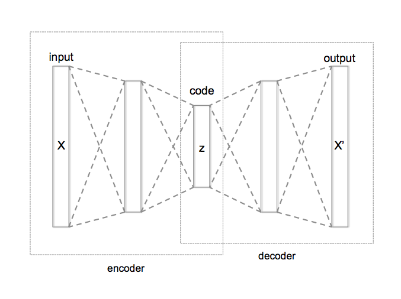

Suppose there’s three layers *X*, *B*, *Y*, where *Y* is the bottleneck layer.

*B* = *W**X*  
*Y* = *M**B*

We can enforce *M* = *W*<sup>*T*</sup> (instead of a plain 3-layer network) using **tied weights**

$$\widetilde{\frac{\partial E}{\partial W}} = \widetilde{\frac{\partial E}{\partial M^T}} = \frac{1}{2}(\frac{\partial E}{\partial W} + \frac{\partial E}{\partial M^T})$$

## Restricted Boltzmann Machines

- Two layers of nodes that are fully connected
  - 1 visible layer *v⃗*
  - 1 hidden layer *h⃗*
- Each node is either 1 or 0
- Probability a node is on depends on neighbouring nodes and connection weights

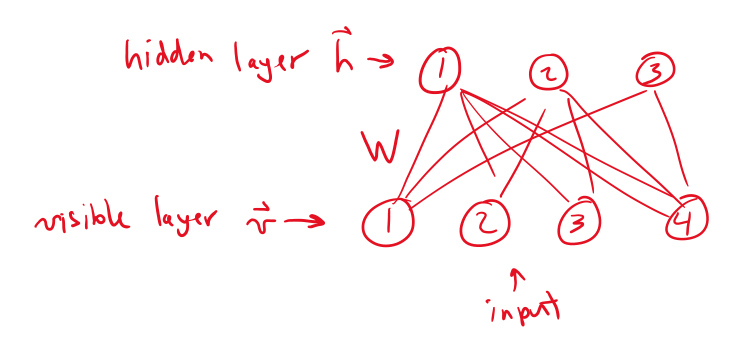

- The *energy* of the network *E*(*v⃗*, *h⃗*) = − *v⃗**W**h⃗*<sup>*T*</sup> + *v⃗**b⃗*<sup>*T*</sup> + *h⃗**c⃗*<sup>*T*</sup>
  - − *v⃗**W**h⃗*<sup>*T*</sup> is when nodes *i* and *j* are on simultaneously
  - *v⃗**b⃗*<sup>*T*</sup> and *v**e**c**h**c⃗*<sup>*T*</sup> are the energy incurred by turning a node on
- When you flip a node *v*<sub>*k*</sub> from off to on, there is an *energy gap*
  - *δ**E*<sub>*k*</sub> = *E*(*v*<sub>*k*</sub> off) − *E*(*v*<sub>*k*</sub> on) = ∑<sub>*j*</sub>*w*<sub>*k**j*</sub>*h*<sub>*j*</sub> − *b*<sub>*k*</sub>
  - If *δ**E*<sub>*k*</sub> > 0, ‘on’ is lower energy so set *v*<sub>*k*</sub> = 1
  - If *δ**E*<sub>*k*</sub> < 0, ‘off’ is lower energy so set *v*<sub>*k*</sub> = 0
  - Energy gap of a node depends on sates of other nodes
- Use the **Boltzmann distribution** to avoid getting stuck in a local minima
  - $P(v_k = 1) = \frac{1}{1+e^{-\delta E_k / T}}$
  - Temperature *T* determines how steep the curve is
- To update node *k*:
  1. Compute *δ**E*<sub>*k*</sub>
  2. Evaluate *p* = *P*(*v*<sub>*k*</sub> = 1) ∈ (0, 1)
  3. Choose a uniform random number *r* ∈ [0, 1]
  4. If *p* > *r*, set node to ‘on’, else ‘off’
- RBM will jump from state to state, usually occupying lower-energy states
- Change weights and biases so that the network states are relevant

### Learning Using Contrastive Divergence

- Recognition: up pass from visible to hidden
- Generative: down pass from hidden to visible
- Given a visible pattern, we want to be able to generate visible states close to what we started with
- Hidden nodes are a *new, more efficient representation* of the patterns in the ‘universe’
- **Contrastive Divergence**: comparison between original input and how well it reconstructed the resulting hidden-layer state

# Recurrent Neural Networks

## Problem

- We sometimes need to process input that depends on what came before
  - e.g Predict next work in a sentence
- Solution 1: Take entire sequence as input
  - Network can only handle fixed length sequences
  - No processing can occur until the entire sequence is given
- Solution 2: *Recurrent Neural Network*
  - Allow the state of the network to depend on new input as well as its previous state

## Recurrent Neural Network (RNN)

- Allow the state of the network to depend on new input as well as its previous state
- Hidden layer has state
- Training:
  - Unroll the network through time

### Feedforward Through Time

$$\begin{align*} %*
h^1 &= \sigma(s^1) = \sigma(Ux^1 + b) \\
y^1 &= \sigma(z^1) = \sigma(Vh^1 + c) \\
\end{align*} %*$$

$$\begin{align*} %*
h^i &= \sigma(s^i) = \sigma(Ux^i + Wh^{i-1} + b) \\
y^i &= \sigma(z^i) = \sigma(Vh^i + c) \\
\end{align*} %*$$

Error:
$$E(y^1,\dots,y^\tau,t^1,\dots,t^\tau) = \sum_{i=1}^\tau C(y^i, t^i) \alpha_i$$
where *α*<sub>*i*</sub> is an optional weight factor to give earlier or later outputs more importance

### Backpropagation Through Time

$$\begin{align*} %*
\frac{\delta E}{\delta z^\tau} &= \frac{\delta E}{\delta y^\tau} \odot \frac{\delta y^\tau}{\delta z^\tau} = \frac{\delta E}{\delta z^\tau} \odot \sigma'(z^\tau) \\
\frac{\delta E}{\delta z^\tau} &= \frac{\delta z^\tau}{\delta h^\tau} \frac{\delta E}{\delta z^\tau} = V^T \frac{\delta E}{\delta z^\tau}
\end{align*} %*$$
$$\begin{align*} %*
\frac{\delta E}{\delta h^i}
&= \frac{\delta C(y^i,t^i)}{\delta h^i} + \frac{\delta E}{\delta z^{i+1}} \frac{\delta h^{i+1}}{\delta h^{i}} \\
&= V^T \frac{\delta C(y^i,t^i)}{\delta y^i} \odot \sigma'(z^i) + W^T \sigma'(s^{i+1}) \odot \frac{\delta E}{\delta h^{i+1}}
\end{align*} %*$$

## Long Short-Term Memory (LSTM)

- Problem:
  - Difficult to keep information in memory for a long time
  - Instability due to exploding or vanishing gradients
- Solution:
  - Add a hidden state that persists from step to step that is not multiplied by the connection weights
  - The state *c* can be incremented, erased, or outputted depending on *h* and *x* values

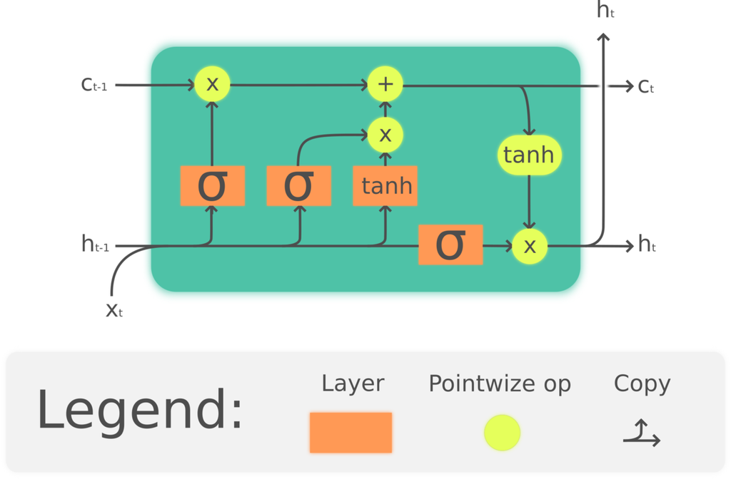

### Gates

- Forget Gate: *f*<sub>*t*</sub> = *σ*(*W*<sub>*f*</sub>*v*<sub>*t*</sub> + *b*<sub>*f*</sub>)
- Input Gate: *i*<sub>*t*</sub> = *σ*(*W*<sub>*i*</sub>*v*<sub>*t*</sub> + *b*<sub>*i*</sub>)
  - Input: $\tilde{C_t} = \tanh(W_Cv_t + b_C)$
  - Combine input with non-forgotten state: $C_t = f_t \odot C_{t-1} + i_t \odot \tilde{C_t}$
- Output Gate: *f*<sub>*o*</sub> = *σ*(*W*<sub>*o*</sub>*v*<sub>*t*</sub> + *b*<sub>*o*</sub>)
- Output: *h*<sub>*t*</sub> = *o*<sub>*t*</sub> ⊙ tanh (*C*<sub>*t*</sub>)

## Neural Coding

Firing rate of a LIF neuron:
$$G(J) = \begin{cases}
\frac{1}{\tau_{ref} - \tau_m \ln(1 - \frac{1}{v_in})} &\text{for $v_{in} > 1$} \\
0 & \text{otherwise}
\end{cases}$$

- We can sample firing rate of neurons in response to an environment value, we can characterize the activity of a neuron with respect to that environment quantity.

- *J*(*x*): is the current entering the neuron for stimulus *x*
- *J*<sub>*t**h*</sub>: threshold
- *τ*<sub>*m*</sub>: membrane time constant
- *τ*<sub>*r**e**f*</sub>: refractory period
- *α*: gain
- *β*: bias
- *e*: encoder
- **Decoding**: given *tuning curves,* estimate the encoded values

### Optimal Linear Decoding

Let *X* ∈ ℝ<sup>*P* × 1</sup> be a column vector containing *x*-values  
Let *A* ∈ ℝ<sup>*P* × *N*</sup> be a matrix where each row contains the activities of *N* neurons for the corresponding *x*-value

We want to find the set of decoding weights *D* ∈ ℝ<sup>*N* × 1</sup>

#### Least Squares Solution

1. Normal equations
   - Efficient, but can be unstable
     $$\begin{align*}
     A^T(AD-X) &= 0 \\
     A^TAD &= A^TX \\
     D &= (A^TA)^{-1}A^TX \\
     &= A^+X
     \end{align*}$$
2. SVD
   - Expensive, but stable

   Let *U**σ**V*<sup>*T*</sup> = *A*
   $$\begin{align*}
   Ax &= b \\
   U^TU\sigmaV^Tx &= Y^Tb \\
   \sigmaV^Tx &= U^Tb \\
   V^Tx &= \sigma^{-1}U^Tb \\
   x = V\sigma^{-1}U^Tb \\
   \end{align*}$$

### Behavioural Sampling

1. Choose a sampling of stimulus values and store them in *X* ∈ ℝ<sup>*P* × 1</sup>
2. Present each stimulus to the animal and measure neural responses *A* ∈ ℙ × ℕ
3. Solve for decoders *D* = argmin_*D*∥*A**D* − *X*∥<sub>2</sub><sup>2</sup>
   - Can also decode *f*(*x*)
4. Use decoder to predict stimulus from only the neural activities

### Tuning Curve

# Advanced Topics

## Convolutional Neural Networks

- Neurons are sparsely connected, unlike the fully connected layers we were looking at earlier
- e.g Visual system
  - One part of the visual field only excites a small patch of neurons in V1
  - **Retinotopic mapping**: topological mapping between the visual field and the surface of the cortex
  - The *footprint* of a region in the visual field gets larger as you progress up through the layers
  - In V2, the neurons are influenced by a bigger part of the visual field
  - By the last layer, the neurons are influenced by all of the visual field

### Convolution

- Continuous domain: (*f* ∘ *g*)(*x*) = ∫<sub>− ∞</sub><sup>∞</sup>*f*(*s*)*g*(*x* − *s*) *d**s*
  - *f*, *g* : ℝ → ℝ
- Discrete domain: $(f \circ g)_m = \sum_{n=0}^{N-1} f_n g_{m-n}$
  - *f*, *g* ∈ ℝ<sup>*N*</sup>
- 2D: (*f* ∘ *g*)<sub>*i*, *j*</sub> = ∑<sub>*m*</sub>∑<sub>*n*</sub>*f*<sub>*i*, *j*</sub>*g*<sub>*m* − *i*, *n* − *j*</sub>
  - e.g Image *f*, conv-kernel (feature) *g* -> feature map or activation map

## Vector Embeddings

- We used vectors to represent inputs and outputs
  - e.g 2 = [0,0,1,0,0,0,0,0,0,0]
- This gets very complex for words
- **Vocabulary**: set of all words encountered in a dataset
- We can order and index the vocabulary to represent words using one-hot vectors
- In NLP, different words can be used to form a similar meaning
  - This isn’t represented using one-hot
  - We can form synonym groups, but where do you draw the line?

### Predicting Word Pairs

- Look at how often words occur together in sentences
  - e.g Trump, Washington
  - e.g Sunday, night
  - e.g climate, change
- Count nearby as within `d` words (e.g `d=2`)
  - e.g “the quick brown fox jumps over the lazy dog.”
    - (the, quick) (the, brown) (quick, the) (quick, brown) (quick, fox)
- Try to predict the word occurences using a 3-layer neural network
  - Input: one-hot word vector
  - Output: probability of a word’s co-occurrence

*y* = *f*(*v*, *θ*), *v* ∈ 𝕎  
*y* = ℙ<sup>*N**v*</sup> = {*p* ∈ ℝ<sup>*N**v*</sup>}

- *y*<sub>*i*</sub> is the probability that word *i* is nearby *v*
- Last layer activation should be softmax to make it work as a probability
- Bottleneck hidden layer to force a compressed representation (an **embedding**), requiring similar words to take on similar representations
- `word2vec`
  - Popular embedding strategy for words
  - Additional tricks
    - Common phrases are new words (e.g New York)
    - Randomly ignores very common words (e.g the)
    - Negative Sampling: backprop only some of the negative cases
      - Since vectors are very sparse
- Embedding space is low-dimensional where similar words are mapped to similar locations
  - Similar to Self Organizing Maps
  - Words with similar meaning likely co-occur with the same set of words
    - So output should be similar
    - So similar hidden-layer activation
  - Use cosine angle to measure distance between vectors
    - e.g ‘kick’, ‘ball’ = 0.81
    - e.g ‘kick’, ‘building’ = -0.05
  - You can do vector addition on the representations
    - e.g king - man + woman = queen